# Arctic Wind Analysis

Pat LaChapelle<sup>1,2</sup>  
Dr. Madison Smith<sup>1,3</sup>  
University of Washington Applied Physics Lab  
pgl3@uw.edu  
www.patlachapelle.us  
November 2019-current  
<sub>1 - University of Washington</sub>

## Overview

This Notebook is purposed for the documentation of my research conducted under the Supervision of Dr. Madison Smith (Applied Physics Lab). This project aims to investigate wind patterns in arctic regions as a method of determining feasibilities of prospective experiments in Dr. Smith's upcoming Arctic expedition. Published research suggests a correlation between sustained wind speeds below 6 m/s and increased temperature/decreased salinity in arctic open-water ice leads (Holland, 2003). The combination of higher temperature and lower salinity would lead to a higher differential of lateral ice melting while basal and surface melting would *hypothetically* remain constant. This change in lateral melt is unaccounted for in current climate models. Datasets included in this project are manipulated with xarray, a python package purposed for the creation and manipulation of large datasets.

## Reading in Wind Data

```python
'''
Begin Code
'''
#import necessary packages
import math
import netCDF4
import xarray as xr
import matplotlib
from matplotlib import pyplot as plt
import numpy as np
import pandas as pd
import cartopy.crs as ccrs
import cartopy
from matplotlib.colors import ListedColormap, LinearSegmentedColormap
import imageio
import os
#Finish Importation of Packages

#Clear up error in MatPlotLib, as required when importing the package
from pandas.plotting import register_matplotlib_converters
register_matplotlib_converters()

'''
Begin Merging of Datasets
'''

#Set Desired Range of years
min_year=2010
max_year=2010

#Derive numyears variable
numyears=max_year-min_year+1

#set file path for vwind
Vwindfilepath='WindVelocities/Vwind/vwnd.10m.gauss.'

#create dictionary for vwind of each year
DSV=['']*numyears

#Set file path for uwind
Uwindfilepath='WindVelocities/Uwind/uwnd.10m.gauss.'

#create dictionary for Uwind for each year
DSU=['']*numyears

#set file extension of netCDF4 files & create year dict
fileext='.nc'
year=['']*numyears

#loop for combining datasets
for x in range(numyears):
    year[x]=str(min_year+x)

    DSV[x]=xr.open_dataset(Vwindfilepath+year[x]+fileext)


    DSU[x]=xr.open_dataset(Uwindfilepath+year[x]+fileext)

    if x==0:
        FullWind=xr.merge([DSV[x],DSU[x]])
    else:
        FullWind=xr.merge([FullWind,DSV[x],DSU[x]])

    DSV[x].close()
    DSU[x].close()

del year, fileext, DSV, DSU
#End Merging of Datasets
```

## Isolating Summer Data

Our primary interest lies in Summer data, which can be easily isolated using time indexing in xarray.

```python
#merge Summer Month arrays to make FullWind for summer
FullWind0=xr.merge([FullWind.where(FullWind.time['time.month']==4, drop=True), FullWind.where(FullWind.time['time.month']==5, drop=True), FullWind.where(FullWind.time['time.month']==6, drop=True), FullWind.where(FullWind.time['time.month']==7, drop=True), FullWind.where(FullWind.time['time.month']==8, drop=True)])

#rewrite variables to clear up weird bug
del FullWind
FullWind=FullWind0
del FullWind0

#Display the months in the Dataset
FullWind.time.dt.month
```

```
<xarray.DataArray 'month' (time: 153)>
array([4, 4, 4, 4, 4, 4, 4, 4, 4, 4, 4, 4, 4, 4, 4, 4, 4, 4, 4, 4, 4, 4,
       4, 4, 4, 4, 4, 4, 4, 4, 5, 5, 5, 5, 5, 5, 5, 5, 5, 5, 5, 5, 5, 5,
       5, 5, 5, 5, 5, 5, 5, 5, 5, 5, 5, 5, 5, 5, 5, 5, 5, 6, 6, 6, 6, 6,
       6, 6, 6, 6, 6, 6, 6, 6, 6, 6, 6, 6, 6, 6, 6, 6, 6, 6, 6, 6, 6, 6,
       6, 6, 6, 7, 7, 7, 7, 7, 7, 7, 7, 7, 7, 7, 7, 7, 7, 7, 7, 7, 7, 7,
       7, 7, 7, 7, 7, 7, 7, 7, 7, 7, 7, 7, 8, 8, 8, 8, 8, 8, 8, 8, 8, 8,
       8, 8, 8, 8, 8, 8, 8, 8, 8, 8, 8, 8, 8, 8, 8, 8, 8, 8, 8, 8, 8],
      dtype=int64)
Coordinates:
  * time     (time) datetime64[ns] 2010-04-01 2010-04-02 ... 2010-08-31
```

## Creating a Mask for the Data

Given that we are investigating the wind reanalysis data for purposes related to sea ice, it is necessary to mask data over land as wind speeds interact differently with land than they do with open ocean/sea ice. To do this, we will use the high resolution land/sea mask provided with NCEP/NCAR data, which has a resolution of 720 latitude coordinates, and 1440 longitude coordinates.

This mask is rotated from the actual values by 180 degrees longitude (see below)

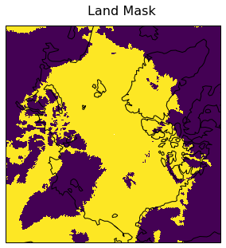

```python
#----------------------------
#Begin Mask
#open Mask
ls_mask=xr.open_dataset('LandSeaMasks/lsmask3.nc')

#remove time coordinate
ls_mask=ls_mask.squeeze()

#Set the mask as the wtp variable ('What to plot")')
wtp=ls_mask.lsmask

#End Mask
#-----------------------------
#-----------------------------
#Begin Plot
#Create fig, set title, etc.
fig=plt.figure(figsize=[10,5])
fig.suptitle('Land Mask', x=0.527, y=0.95, fontsize=16)
ax=plt.axes(projection=ccrs.NorthPolarStereo(180,0))
ax.set_extent([0, 358.125, 65, 90], crs=ccrs.PlateCarree())
ax.imshow(wtp, transform=ccrs.PlateCarree())
ax.coastlines()
plt.show()

#Deleter Variables
del ls_mask, wtp
#End Plot
#-------------------------------
```

### Adjusting the Mask

See how Greenland is off by 180 degrees? We can fix this by using the roll command in numpy, which rotates the values about a selected axis.

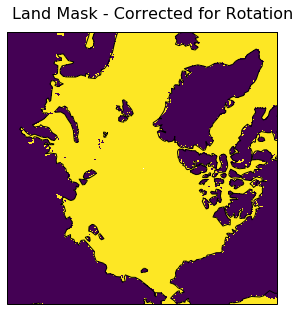

```python
#--------------------------------------
#Loading and altering mask
#open Mask
ls_mask=xr.open_dataset('LandSeaMasks/lsmask3.nc')
ls_mask=ls_mask.squeeze()

#Rotate mask
rotated=np.roll(ls_mask.lsmask.values,720, axis=1)

#Set Lat/lon coordinates
lat=ls_mask.lat
lon=ls_mask.lon

#Create Data Array in xarray w/ masked coordinates
maskvar=xr.DataArray(rotated, coords=[lat,lon], dims=['lat','lon'])

#Set maskvar as the wtp variable
wtp=maskvar;

#End loading and altering mask
#-------------------------------

#-------------------------------
#Begin Plot
#Create Plot
fig=plt.figure(figsize=[10,5])
fig.suptitle('Land Mask - Corrected for Rotation', x=0.527, y=0.95, fontsize=16)
ax=plt.axes(projection=ccrs.NorthPolarStereo(180,0))
ax.set_extent([0, 358.125, 65, 90], crs=ccrs.PlateCarree())
ax.imshow(wtp, transform=ccrs.PlateCarree())
ax.coastlines()
plt.show()

del wtp, ls_mask, rotated, maskvar

#End Plot
#-----------------------------------
```

### Reindexing the Dataset & adding the mask

Now that we have the land mask in its proper orientation, we can add the masking coordinates to the dataset. Since we used the high resolution data for the mask (since a lower resolution mask would inevitably produce the undesired result of masking land *and* sea), it is necessary to reindex our data accordingly, so that the latitudes and longitudes of the mask and data match up. The key here is that we are not interpolating our data - such a process would result in some "sea" grid cells becoming an everage of "land" cells and other "sea" cells. Insteas, we reindex the data, using a "nearest value" protocol, which breaks each initial cell into roughly 57 smaller cells, but each of the smaller cells has the exact value of the initial cell.

Finally, we add the mask to the data as a coordinate, so that it can easily be used as a parameter upon which the other variables rely.

```python
#Getting the Mask
ls_mask=xr.open_dataset('LandSeaMasks/lsmask3.nc')

#eliminate time coordinate from mask dataset
ls_mask=ls_mask.squeeze()

#Pull latitude and Longitude dimensions from mask data
lat=ls_mask.lat
lon=ls_mask.lon

#rotating the mask
rotated=np.roll(ls_mask.lsmask.values,720, axis=1)

#Creating xr Data Array for the mask
mask=xr.DataArray(rotated, coords=[lat,lon], dims=['lat','lon'])

#reindexing the Wind dataset
FullWind=FullWind.reindex_like(mask, 'nearest')

#Adding the mask to the dataset
FullWind.coords['mask']=(('lat','lon'), mask)

#Close mask variables
mask.close()
ls_mask.close()

#delete unnecessary variables
del lat, lon, rotated, ls_mask
```

Now the Wind Dataset contains a mask coordinate

```python
#Display Coordinates
FullWind.coords
```

```
Coordinates:
  * lat      (lat) float64 -89.88 -89.62 -89.38 -89.12 ... 89.38 89.62 89.88
  * lon      (lon) float64 0.125 0.375 0.625 0.875 ... 359.1 359.4 359.6 359.9
  * time     (time) datetime64[ns] 2010-04-01 2010-04-02 ... 2010-08-31
    mask     (lat, lon) float32 0.0 0.0 0.0 0.0 0.0 0.0 ... 1.0 1.0 1.0 1.0 1.0
```

## Isolating Arctic data & adding Wind Magnitude Variable

```python
#Adding Variable for Wind Magnitude
FullWind=FullWind.assign(WindMag = lambda FullWind: (FullWind.vwnd**2+FullWind.uwnd**2)**0.5)


#Isolating arctic regions
#FullWind_arctic=xr.merge([FullWind.vwnd[:,619:720,:], FullWind.uwnd[:,619:720,:], FullWind.WindMag[:,619:720,:]])

#Close Dataset FullWind
FullWind.close()
```

## Plotting Average Wind velocities Over Summer Months at each grid cell

Now that we have masked and isolated our desired data, we can plot the average wind velocities over the Summer Months of the years in the dataset.

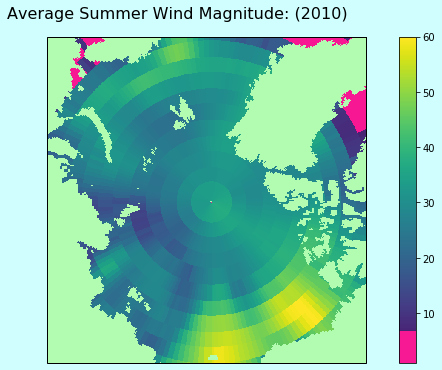

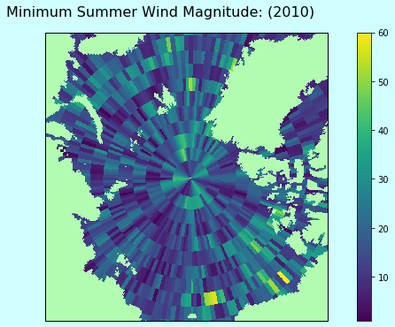

```python
#Creating map arrays for mean, min and max plots
fwa_maskedwm_mean=FullWind['WindMag'].mean('time').where(FullWind.mask==1)
fwa_maskedwm_min=FullWind['WindMag'].min('time').where(FullWind.mask==1)

wtp=fwa_maskedwm_mean

#Creating label for year range
if numyears==1:
    label='Summer Wind Magnitude: ('+str(min_year)+')'
else:
    label='Summer Wind Magnitude: ('+str(min_year)+'-'+str(max_year)+')'

#get colormap
viridis = matplotlib.cm.get_cmap('viridis', 256)
newcolors = viridis(np.linspace(0, 1, 256))
pink = np.array([248/256, 24/256, 148/256, 1])
newcolors[:25, :] = pink
newcmp = ListedColormap(newcolors)

#set land color to light green
newcmp.set_bad(color='#b1fcb1')
viridis.set_bad(color='#b1fcb1')

#create plot
fig=plt.figure(figsize=[12,6])
fig.patch.set_facecolor('xkcd:pale blue')
fig.suptitle('Average '+label, x=0.527, y=0.95, fontsize=16)
ax=plt.axes(projection=ccrs.NorthPolarStereo(180,0))
ax.set_extent([0, 358.125, 70, 90], crs=ccrs.PlateCarree())
ax.imshow(wtp, cmap=newcmp, transform=ccrs.PlateCarree())
psm=ax.pcolormesh(wtp, cmap=newcmp, rasterized=True, vmin=1, vmax=60)
fig.colorbar(psm, ax=ax)

plt.show()

plt.savefig('Plots/Maps/Avg_Sum_WindMag_2010.png', bbox_inches="tight")

wtp=fwa_maskedwm_min

#create plot
fig=plt.figure(figsize=[12,6])
fig.patch.set_facecolor('xkcd:pale blue')
fig.suptitle('Minimum '+label, x=0.527, y=0.95, fontsize=16)
ax=plt.axes(projection=ccrs.NorthPolarStereo(180,0))
ax.set_extent([0, 358.125, 70, 90], crs=ccrs.PlateCarree())
ax.imshow(wtp, cmap=viridis, transform=ccrs.PlateCarree())
psm=ax.pcolormesh(wtp, cmap=viridis, rasterized=True, vmin=1, vmax=60)
fig.colorbar(psm, ax=ax)

plt.show()

plt.savefig('Plots/Maps/Min_Sum_WindMag_2010.png', bbox_inches='tight')
```

## Creating an Index for Days below 6 m/s

```python
#Rewrite Wind Variable
db6=FullWind.WindMag.where(FullWind.WindMag<=6,0)
db6=db6.where(FullWind.WindMag>6,1)

db6=xr.DataArray(db6, coords=[FullWind.time,FullWind.lat,FullWind.lon], dims=['time','lat','lon'])

#Write dictionaries for Writing Dataset
data_vars={
    'vwnd':FullWind.vwnd,
    'uwnd':FullWind.uwnd,
    'WindMag':FullWind.WindMag,
    'db6':db6,
}
coords={
    'time':FullWind.time,
    'lat':FullWind.lat,
    'lon':FullWind.lon,
}

FullWind=xr.Dataset(data_vars, coords)
```

[figure not shown]

```python
db6map=FullWind['db6'].sum('time').where(FullWind.mask==1)
newcmp = matplotlib.cm.get_cmap('YlOrRd')
#set land color to light green
newcmp.set_bad(color='#b1fcb1')

wtp=db6map

#create plot
fig=plt.figure(figsize=[12,6])
fig.patch.set_facecolor('xkcd:pale blue')
fig.suptitle('Summer 2010: Days of Wind speed below 6 m/s', x=0.527, y=0.95, fontsize=16)
ax=plt.axes(projection=ccrs.NorthPolarStereo(180,0))
ax.set_extent([0, 358.125, 70, 90], crs=ccrs.PlateCarree())
ax.imshow(wtp, cmap=newcmp, transform=ccrs.PlateCarree())
psm=ax.pcolormesh(wtp, cmap=newcmp, rasterized=True, vmin=1, vmax=365)
fig.colorbar(psm, ax=ax)

plt.show()

plt.savefig('Plots/Maps/DaysBelow62010.png')
```